# L08 - More Data Wrangling

Padma Tanikella

July 12, 2024

## Midterm and Final Project details

- Midterm will be held in class (10:45 am - 11:45 am) on July 19th.
- Information and practice questions for the midterm are provided under the “Midterm” module.
- Final project details are provided under the “Final project” module.
- I have included a list of publicly available datasets. You can use data from one of these websites or from a different website of your choice.
- Make sure to check how to cite your data source. You must add the citation to your final report.

## Review of some important concepts

## Three Important Concepts

1. Data can be usefully organized into tables with “cases” and “variables.”
   - In “tidy data” every case is the same sort of thing (e.g. a person, a car, a year, a country in a year)
   - We sometimes even modify data in order to change what the cases represent in order to better represent a point.
2. Data graphics and “glyph-ready” data
   - each case corresponds to a “glyph” (mark) on the graph
   - each variable to a graphical attribute of that glyph such as x- or y-position, color, size, length, shape, etc.
   - same is true for more technical tools (e.g., models, predictions, etc.)
3. When data are not yet in glyph-ready form, you can transform (i.e. wrangle) them into glyph-ready form.
   - Such transformations are accomplished by performing one or more of a small set of basic operations on data tables
   - This is the work of data “verbs”
- So far, all the data sets we have come across have variables like “Age”, “Sex”, “Income” etc. The experimental unit is usually an individual, group of individuals, a country etc.
- Let us look at a different kind of data - fMRI data. Ignore details like how to read fMRI data into R, what R functions to use etc.
- The purpose of this example is to look at an interesting new data set and see if we can use the concepts we learnt so far.

### About the dataset

- Data Source: [OpenfMRI, CNP data](https://openfmri.org/dataset/ds000030/)
- The study includes imaging of a
  - large group of healthy individuals from the community (138 subjects)
  - samples of individuals diagnosed with schizoprenia (58)
  - bipolar disorder (49)
  - and ADHD (45).
- Age group of participants: 21-50
- Participants recruited by community advertisements from the Los Angeles area.
- Participants completed extensive neuropsychogical testing, in addition to fMRI scanning.
- Participants should have completed at least 8 years of education
- Participants were screened for neurological disease, history of head injury, use of psychoactive medications, substance dependence within past 6 months, history of major mental illness or ADHD, and current mood or anxiety disorder.
- ……

This is just a subset of information about the study conducted at UCLA. Check the OpenfMRI website for more information. Let us focus on how the dataset looks like.

We are looking at fMRI data associated with just one subject (Subject 10159) while performing some task. We will ignore the exact details of this task for now.

```r
fmri_data
```

```
NIfTI-1 format
  Type            : nifti
  Data Type       : 4 (INT16)
  Bits per Pixel  : 16
  Slice Code      : 5 (Alt_Inc2)
  Intent Code     : 0 (None)
  Qform Code      : 1 (Scanner_Anat)
  Sform Code      : 1 (Scanner_Anat)
  Dimension       : 64 x 64 x 34 x 267
  Pixel Dimension : 3 x 3 x 4 x 2
  Voxel Units     : mm
  Time Units      : sec
```

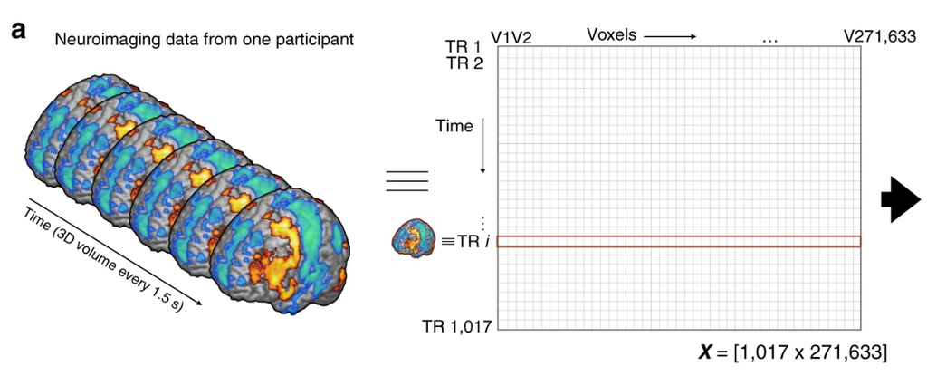

How does the data look like?

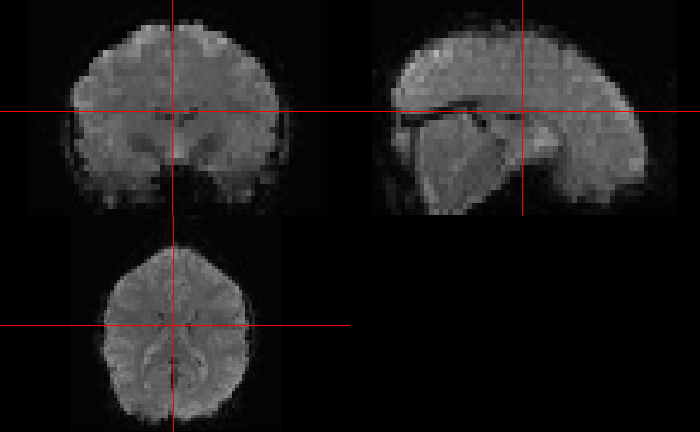

```r
orthographic(fmri_data)
```

Let us look at the intensity for one single voxel.

```r
fmri_data[20,20,30,1]
```

```
[1] 59
```

Let us plot the **time series** data associated with ONE voxel of ONE subject.

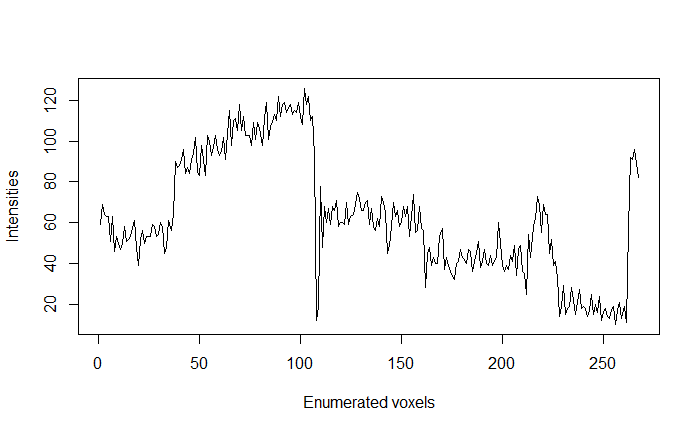

```r
plot(fmri_data[20,20,30,],type='l', xlab = "Enumerated voxels", ylab = "Intensities")
```

### Discussion quesions

- Assume that the dataset we have is the voxel intensities associated with just one subject. How would tidy data look like?
- What is the glyph in the plot of voxel intensities?
- How does glyph ready data look like?

## Classifying functions

- When data are not yet in glyph-ready form, you can transform (i.e. wrangle) them into glyph-ready form.
- Keep in mind that when we are wrangling, we are carrying out actions thus we will need **data verbs**.
- There are several ways we can classify verbs (functions) for data wrangling. The DC textbook presents one way:
  - Reduction Functions: Any function which takes an input (variable) vector ($n \times 1$) and returns a single value as the output (i.e., a scalar ($1 \times 1$)).
  - Transformation Functions: Any function which takes one or more input variables and returns a new variable.
  - Data Verbs: Functions which act upon a data frame and return a new data frame.

Look at the `data-wranglin-activity.Rmd` file posted on Canvas. Perform the necessary data analysis and identify the different data verbs used while data wrangling.

## Interactive graphics

An extremely helpful package is the `esquisse` package. Install the package as usual.

```r
library(esquisse)
# another option is to go to the "Addins" menu
esquisser()
```

Use the [esquisse vignette](https://cran.r-project.org/web/packages/esquisse/vignettes/get-started.html) to understand how `esquisse` interactive graphics work.

Notice that `esquisse` package also provides with the corresponding `ggplot2` syntax required for the graphics.

| species | island | bill_length_mm | bill_depth_mm | flipper_length_mm | body_mass_g | sex | year |
| --- | --- | --- | --- | --- | --- | --- | --- |
| Adelie | Torgersen | 39.1 | 18.7 | 181 | 3750 | male | 2007 |
| Adelie | Torgersen | 39.5 | 17.4 | 186 | 3800 | female | 2007 |
| Adelie | Torgersen | 40.3 | 18.0 | 195 | 3250 | female | 2007 |
| Adelie | Torgersen | NA | NA | NA | NA | NA | 2007 |
| Adelie | Torgersen | 36.7 | 19.3 | 193 | 3450 | female | 2007 |
| Adelie | Torgersen | 39.3 | 20.6 | 190 | 3650 | male | 2007 |
| Adelie | Torgersen | 38.9 | 17.8 | 181 | 3625 | female | 2007 |
| Adelie | Torgersen | 39.2 | 19.6 | 195 | 4675 | male | 2007 |
| Adelie | Torgersen | 34.1 | 18.1 | 193 | 3475 | NA | 2007 |
| Adelie | Torgersen | 42.0 | 20.2 | 190 | 4250 | NA | 2007 |

[output cut: 334 more lines]

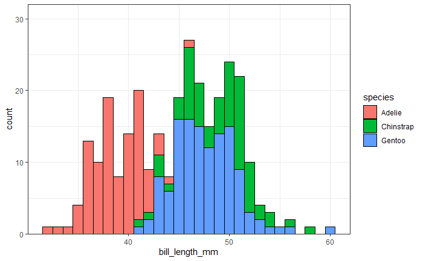